# M1 Midterm I

Data Visualization (STAT 302)

Noah Holubow

## Overview

Exercises 1 & 2 ask you to replicate plots and provide some basic insight into what the graphics are communicating. Exercise 3 asks you to provide short descriptions/explanations regarding issues and concepts in `ggplot2`.

You are free to use any resource at your disposal such as notes, past labs, the internet, fellow students, instructor, TA, etc. However, do not simply copy and paste solutions. This is a chance for you to assess how well you have come to know `ggplot2` and determine if you are developing the practical skills needed to utilize `ggplot2` in the future.

## Datasets

We will need the instructor provided `stephen_curry_shotdata_2014_15.txt` dataset and the `nbahalfcourt.jpg`. The variables should be fairly straightforward after some inspection of the dataset, but we have provided a description of variables just in case.

- `GAME_ID` - Unique ID for each game during the season
- `PLAYER_ID` - Unique player ID
- `PLAYER_NAME` - Player’s name
- `TEAM_ID` - Unique team ID
- `TEAM_NAME` - Team name
- `PERIOD` - Quarter or period of the game
- `MINUTES_REMAINING` - Minutes remaining in quarter/period
- `SECONDS_REMAINING` - Seconds remaining in quarter/period
- `EVENT_TYPE` - `Missed Shot` or `Made Shot`
- `SHOT_DISTANCE` - Shot distance in feet
- `LOC_X` - X location of shot attempt according to tracking system
- `LOC_Y` - Y location of shot attempt according to tracking system

```r
# Load package(s)
library(tidyverse)
library(patchwork)
library(grid)
library(jpeg)

# Read in the dataset(s)
curry <- read_delim(file = "data/stephen_curry_shotdata_2014_15.txt", delim = "|") %>%
  janitor::clean_names()
```

## Exercises

Complete the following exercises.

### Exercise 1

Figures for this exercise have width 6 inches and height 4 inches.

Using the `stephen_curry_shotdata_2014_15.txt` dataset replicate, as close as possible, the 2 graphics below. After replicating the plots provide a summary of what the graphics indicate about Stephen Curry’s shot selection (i.e. distance from hoop) and shot make/miss rate and how they relate/compare across distance and game time (i.e. across quarters/periods).

#### Plot 1

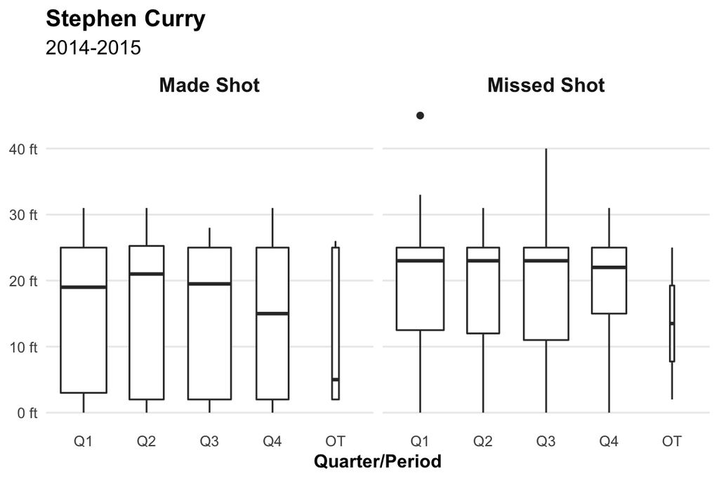

```r
# plot
curry %>%
  mutate(
    period = factor(period, c("Q1", "Q2", "Q3", "Q4", "OT"), # adding factor for each period
    levels =  c("1", "2", "3", "4", "5"), # reordering periods
    labels = c("Q1", "Q2", "Q3", "Q4", "OT")), # relabeling periods
  ) %>%
  ggplot(aes(x = period, y = shot_distance)) + # defining mapping variables
  geom_boxplot(varwidth = TRUE) + # creating boxplot with variable width
  facet_grid(~ event_type) + # faceting around event type
  labs(
    x = "Quarter/Period", # x-axis label
    y = NULL, # y-axis label
    title = "Stephen Curry", # title
    subtitle = "2014-2015" # subtitle
  ) +
  scale_y_continuous(labels = scales::label_number(prefix = "", suffix = " ft")) + # y-axis ticks
  theme_minimal() + # minimal theme
  theme(
    plot.title = element_text(face = "bold", size = 14), # bolding title, changing size
    plot.subtitle = element_text(size = 12),
    strip.text.x = element_text(face = "bold", size = 12), # bolding facet titles
    axis.title = element_text(face = "bold"), # bolding axis labels
    panel.grid.major.x = element_blank(), # removing major vertical lines
    panel.grid.minor.y = element_blank() # removing minor horizontal lines
  )
```

**Hints for second plot:**

- Use `minimal` theme and adjust from there
- Useful hex colors: `"#5D3A9B"`, `"#E66100"`
- No padding on vertical axis

#### Plot 2

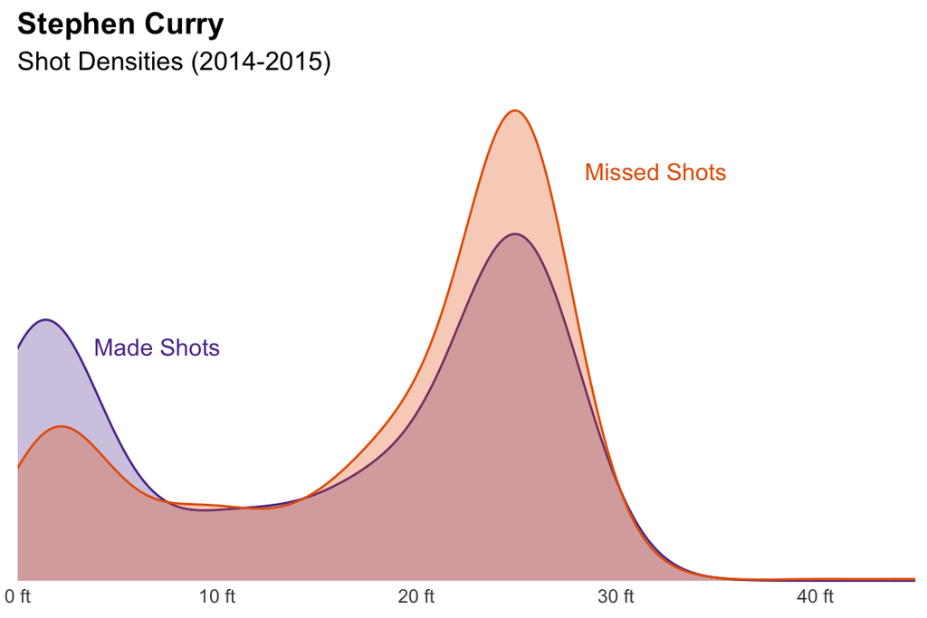

```r
# plot
curry %>%
  ggplot(aes(x = shot_distance)) + # defining mapping variables
  geom_density( # setting up density plot
    aes(
      color = event_type, # mapping event type to line color aesthetic
      fill = event_type # mapping event type to fill aesthetic
      ),
    alpha = 0.3, # setting transparency
    show.legend = FALSE
    ) +
  scale_fill_manual(values = c("#5D3A9B", "#E66100")) + # defining fill colors
  scale_color_manual(values = c("#5D3A9B", "#E66100")) + # defining line colors
  labs(
    x = NULL, # no x-axis label
    y = NULL, # no y-axis label
    title = "Stephen Curry",
    subtitle = "Shot Densities (2014-2015)"
  ) +
  scale_x_continuous(labels = scales::label_number(suffix = " ft"), expand = c(0,0)) + # modifying axis ticks
  scale_y_continuous(labels = NULL) +
  theme_minimal() + # minimal theme
  annotate(
    geom = "text", # adding text annotation
    x = 7, # annotation x-value
    y = 0.04, # annotation y-value
    label = "Made Shots", # annotation text
    color = "#5D3A9B" # annotation color
  ) +
   annotate(
    geom = "text", # adding text annotation
    x = 32, # annotation x-value
    y = 0.07, # annotation y-value
    label = "Missed Shots", # annotation text
    color = "#E66100" # annotation color
  ) +
  theme(
    plot.title = element_text(face = "bold", size = 14), # bolding title, changing size
    plot.subtitle = element_text(size = 12),
    panel.grid = element_blank(), # removing grid lines
    axis.text.x = element_text(margin = margin(-10,0,0,0))
  )
```

### Exercise 2

Figures for this exercise have width 7 inches and height 7 inches.

Using the `stephen_curry_shotdata_2014_15.txt` dataset replicate, as close as possible, the 2 graphics below. We have provided some skeleton code to get you started. You should start with the skeleton code and add to it to replicate the graphics. Where indicated, add comments to describe what the provided code is doing.

After examining the two graphics, what do you conclude about Stephen Curry’s shot selection (i.e. distance form hoop) for the 2014-2015 season? Out of the four graphics (two from Exercise 1 and two from Exercise 2), which graphic(s) do you find the most useful when trying to understand Stephen Curry’s shot selection? If you find them all useful, explain what information is better communicated in each.

#### Plot 1

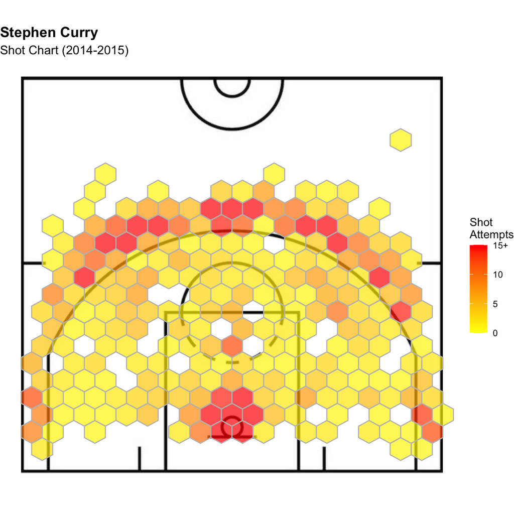

```r
# loading court graphic
court <- rasterGrob(readJPEG(source = "data/nbahalfcourt.jpg"), # reading in court graphic
  width = unit(1, "npc"), height = unit(1, "npc") # setting dimensions for court graphic
)

# plot
curry %>%
ggplot(aes(x = loc_x, y = loc_y)) + # defining mapping variables
  # adding basketball court image
  annotation_custom(
    grob = court, # adding court annotation graphic
    xmin = -250, xmax = 250, # setting x-coordinate bounds
    ymin = -52, ymax = 418 # setting y-coordinate bounds
  ) +
  coord_fixed() + # forcing specified ratio between data units on axes
  xlim(250, -250) + # x-axis limits
  ylim(-52, 418) + # y-axis limits
  geom_hex( # adding hex geom
      bins = 20, # defining number of bins for data
      alpha = 0.7, # defining transparency of hexagons
      color = "gray") + # defining outline color of hexagons
  scale_fill_gradient(
    low = "yellow", # setting color for low values of fill gradient
    high = "red", # setting color for high values of fill gradient
    limits = c(0, 15), # limits for number of shots taken for given hexagon
    na.value = "red", # fill color for NA values
    name = "Shot\nAttempts", # legend title
    labels = c("0", "5", "10", "15+")) + # legend bin labels
  labs(
    title = "Stephen Curry", # plot title
    subtitle = "Shot Chart (2014-2015)" # plot subtitle
  ) +
  theme_void() + # no theme
  theme(
    plot.title = element_text(face = "bold", size = 14), # bolding title, changing size
    plot.subtitle = element_text(size = 12) # changing subtitle size
  )
```

#### Plot 2

**Hint:**

- Useful hex colors: `"#5D3A9B"`, `"#E66100"`

**Answer:**

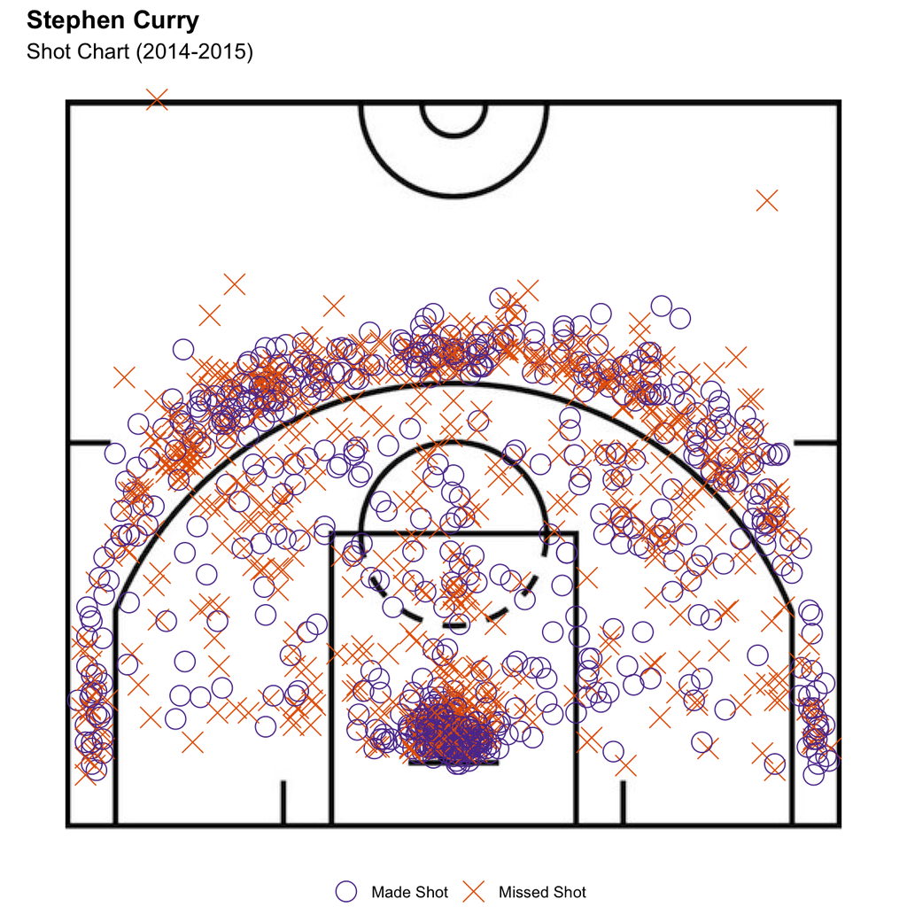

```r
# plot
curry %>%
ggplot(aes(x = loc_x, y = loc_y)) + # defining mapping variables
 # adding basketball court image
  annotation_custom(
    grob = court, # adding court annotation graphic
    xmin = -250, xmax = 250, # setting x-coordinate bounds
    ymin = -52, ymax = 418 # setting y-coordinate bounds
  ) +
  coord_fixed() + # forcing specified ratio between data units on axes
  xlim(250, -250) + # x-axis limits
  ylim(-52, 418) + # y-axis limits
  geom_point( # creating scatterplot
    aes(
      color = event_type, # mapping color aesthetic to event type
      shape = event_type # mapping shape aesthetic to event type
      ),
    size = 5 # setting size of points
  ) +
  scale_shape_manual(
    labels = c("Made Shot", "Missed Shot"), # defining order of event types to map to manual shapes
    values = c(1, 4) # defining manual shape types corresponding to values of event_type
    ) +
  scale_color_manual(
    values = c("#5D3A9B", "#E66100") # manually setting point colors
  ) +
  labs(
    title = "Stephen Curry", # setting title
    subtitle = "Shot Chart (2014-2015)" # setting subtitle
  ) +
  theme_void() + # no theme
  theme(
    plot.title = element_text(face = "bold", size = 14), # bolding title and changing size
    plot.subtitle = element_text(size = 12), # changing size of subtitle
    legend.position = "bottom", # legend at bottom of plot
    legend.title = element_blank(), # no legend title
  )
```

### Exercise 3

##### Part 1

In 3-5 sentences, describe the core concept/idea and structure of the `ggplot2` package.

**Answer: ggplot2 is an R package that contains many helpful functions to produce statistical graphics. Though there are many default settings, the package is extremely customizable and can control nearly any aspect of the plot, which is not true of other graph generating programs like Excel. The entire package is structured around a grammar that must be used to build each component of the graphic iteratively by adding on layers. In addition to the data, all plots are composed of a mapping, which has five components: layers (geoms or stats), scales, coordinates, facets, and themes.**

##### Part 2

Describe each of the following:

1. `ggplot()` **Answer: this is the function used to make complex plots with just a few lines of code. It sets up all the necessary panels, labels, and mapping space.**
2. `aes()` **Answer: this is a key component of every plot and defines the set of aesthetic mappings between variables from your dataset and their visual properties.**
3. `geoms` **Answer: this is a layer that describes how to render each observation. For example, there are geoms for histograms, scatterplots, bar plots, and so on.**
4. `stats` **Answer: these are the underlying statistical transformations that can occur when generating a plot. An example is “bin,” which produces count and density as output variables.**
5. `scales` **Answer: scales control the mapping from data to the actual aesthetics. Scales will use the data to visualize it (color, size, position, shape) and also help control the axes and legends. There are three main types of scales: position, color, and other aesthetics.**
6. `theme()` **Answer: the theme system does not manipulate the rendering of the data or any statistical transformations but rather affects the aesthetic appearance of the plots. Theme lets you control fonts, backgrounds, colors, positions, and so on. These are all the non-data elements that are in the user’s control.**

##### Part 3

Explain the difference between using this code `geom_point(aes(color = VARIABLE))` as opposed to using `geom_point(color = VARIABLE)`. **Answer: aes(color = VARIABLE) will map the color aesthetic to the variable values, thereby plotting points, lines, etc. in a different color for each value the variable takes on. Color outside of the aesthetic argument simply defines the color for all points if a color code is supplied, and setting it equal to a VARIABLE will not work.**